# Métodos de Monte Carlo em Inferência

## Introdução

Métodos de Monte Carlo compõem uma parte significativa de métodos computacionais em Estatística. Anteriormente, discutimos Integração por Monte Carlo. Mas outras aplicações incluem estimação de: - parâmetros da distribuição amostral de uma estatística; - erros quadrados médios - percentis; - probabilidades de cobertura de intervalos de confiança; - poder de testes; - e outras quantidades de interesse.

## Métodos de Monte Carlo para Estimação

Suponha que \(X_1, \dots, X_n\) seja uma amostra aleatória tomada a partir da distribuição de \(X\). O estimador \(\hat{\theta}\) do parâmetro \(\theta\) é a função \(n\)-variada baseada nesta amostra, como mostrado a seguir:

\[ \hat{\theta} = \theta(X_1, \dots, X_n) \]

## Exemplo - Estimação de Monte Carlo e Erro-Padrão

Se \(X_1, \dots, X_n \sim N(0, 1)\), estime \(E |X_1 - X_2|\).

- Gerar \(y_i = (X_{1i}, X_{2i})\);
- Determinar \(g(y_i) = | X_{1i} - X_{2i} |\);
- Retornar: \[\hat{\theta} = \overline{g(Y)}\]

## Exemplo - Estimação do Erro-Padrão

\[\sqrt{V(\bar{X})} = \sqrt{\frac{V(X)}{n}}\] \[\sqrt{V(\overline{g(X)})} = \sqrt{\frac{V(g(X))}{n}}\]

Se \(X_1, \dots, X_n \sim N(0, 1)\), como estimar o erro-padrão do estimador de \(E |X_1 - X_2|\)?

## Exemplo - Estimação do Erro-Quadrado Médio

\[MSE(\hat{\theta}) = E\left[(\hat{\theta}-\theta)^2\right]\]

Se \(m\) amostras de \(X_1^{(j)}, \dots, X_n^{(j)}, \forall j \in 1, \dots, m\) são geradas da distribuição de \(X\), então:

\[\hat{MSE} = \frac{1}{m} \sum_{i=1}^m \left( \hat{\theta}^{(j)}-\theta \right)^2,\]

onde \(\hat{\theta}^{(j)} = \hat{\theta}(x_1^{(j)}, \dots, x_n^{(j)})\).

## MSE para Média Aparada

Se \(X_{(1)}, \dots, X_{(n)}\) são as estatísticas de ordem da amostra \(X_1, \dots, X_n\), então a média aparada de nível \(k\) é:

\[\bar{X}_{[-k]} = \frac{1}{n-2k} \sum_{i=k+1}^{n-k} X_{(i)}.\]

Determine a estimativa de Monte Carlo do \(MSE(\bar{X}_{[-1]})\), assumindo que \(X\sim N(0, 1)\).

## MSE para Média Aparada

1. Defina \(T^{(j)}\) como a \(j\)-ésima réplica de Monte Carlo para \(\bar{X}_{[-1]}\);
2. Determine \(T^{(j)}\), para \(j=1,\dots,m\), repetindo:
   - Gere \(x^{(j)}_1, \dots, x^{(j)}_n\) a partir da distribuição de \(X\);
   - Obtenha as estatísticas de ordem \(x^{(j)}_{(1)}, \dots, x^{(j)}_{(n)}\);
   - Determine \(T^{(j)} = \frac{1}{n-2}\sum_{i=2}^{n-1} x^{(j)}_{(i)}\);
3. Estime \(MSE(T) = \frac{1}{m} \sum_{j=1}^m \left( T^{(j)} - \theta\right)^2 = \frac{1}{m}\sum_{j=1}^m \left( T^{(j)}\right)^2\)

Note que \(\theta = E(X) = E(X_{[-1]}) = 0\), pois \(X \sim N(0,1)\).

## MSE para a Média Aparada

```r
m = 1000
n = 20
tmean = replicate(m, {
 x = rnorm(n)
 y = sort(x)[2:(n-1)]
 mean(y)
})
(mse = mean(tmean^2))
```

```
## [1] 0.05123657
```

```r
var.tmean = mean((tmean-mean(tmean))^2)
(se.tmean = sqrt(var.tmean/m))
```

```
## [1] 0.007157857
```

## Método de Monte Carlo para Estimação de Níveis de Confiança

Se a variável de interesse é \(X \sim F_X\) e \(\theta\) é o parâmetro a ser estimado, então:

1. Para cada réplica de MC (\(j=1, \dots, m\))
   - Gere uma amostra aleatória \(X_1^{(j)}, \dots, X_n^{(j)}\);
   - Determine o intervalo de confiança \(C_j\);
   - Defina \(y_j = I(\theta \in C_j)\).
2. Calcule o nível empírico de confiança usando \(\bar{y}\).

## Nível de Confiança - IC Variância

\[X_1, \dots, X_n \sim N(\mu, \sigma^2)\]

Qual é a quantidade pivotal para \(\sigma^2\)?

\[V = \frac{(n-1)S^2}{\sigma^2} \sim \chi^2_{n-1}\]

Qual é o IC (\(1-\alpha\)) unilateral para a variância?

\[\left[ 0, \frac{(n-1)S^2}{\chi^2_{n-1}(\alpha)} \right]\]

## Nível de Confiança - IC Variância

Então, se \(\mu=0, \sigma=2, n=20, m=1000\) e \(\alpha=0.05\), temos:

```r
mu=0
sigma=2
n=20
m=1000
alpha=0.05
upper = replicate(m, {
    x = rnorm(n, mu, sigma)
    (n-1)*var(x)/qchisq(alpha, n-1)
})
y = sigma^2 < upper
(mean(y))
```

```
## [1] 0.948
```

## Método de Monte Carlo para Estimar Erro Tipo I em um Teste de Hipóteses

1. Para cada réplica \(j=1, \dots, m\):
   - Gere a \(j\)-ésima amostra a partir da distribuição de \(H_0\);
   - Determine a estatística do teste, \(T_j\);
   - Faça a decisão \(I_j = 1\), se \(H_0\) é rejeitada.
2. Calcule a proporção de testes significantes.

## MC em Testes de Hipótese - Erro Tipo I

\[X_1, \dots, X_n \sim N(\mu, \sigma^2)\]

## MC em Testes de Hipótese - Erro Tipo I

```r
mu0=500
sigma=100
n=20
m=100000
alpha=0.05
tstat = replicate(m, {
    x = rnorm(n, mu0, sigma)
    (mean(x)-mu0)/(sd(x)/sqrt(n))
})
I = tstat > qt(1-alpha, n-1)
mean(I)
```

```
## [1] 0.05071
```

## Método de Monte Carlo para Estimar Poder em um Teste de Hipóteses

1. Selecione um valor \(\theta_1\) sob \(H_1\);
2. Para cada réplica \(j=1, \dots, m\):
   - Gere a \(j\)-ésima amostra a partir da distribuição de \(H_1\);
   - Determine a estatística do teste, \(T_j\);
   - Faça a decisão \(I_j = 1\), se \(H_0\) é rejeitada.
3. Calcule a proporção de testes significantes.

## MC em Testes de Hipótese - Poder

\[X_1, \dots, X_n \sim N(\mu, \sigma^2)\]

Calcule o poder do teste para \(H_0: \mu = 500\) vs. \(H_1: \mu > 500\), quando \(\alpha = 0.05\) e \(\sigma=100\). Sob \(H_0\): \[T^{*} = \frac{\bar{X}-500}{S/\sqrt{20}} \sim t_{19}\]

## MC em Testes de Hipótese - Poder

```r
mu0=500
mu1=seq(450, 650, 5)
power = rep(NA, length(mu1))
sigma=100
n=20
m=10000
alpha=0.05
for (i in 1:length(mu1)){
    tstat = replicate(m, {
        x = rnorm(n, mu1[i], sigma)
        (mean(x)-mu0)/(sd(x)/sqrt(n))
    })
    power[i] = mean(tstat > qt(1-alpha, n-1))
}
err = sqrt(power*(1-power)/m)
```

## MC em Testes de Hipótese - Poder

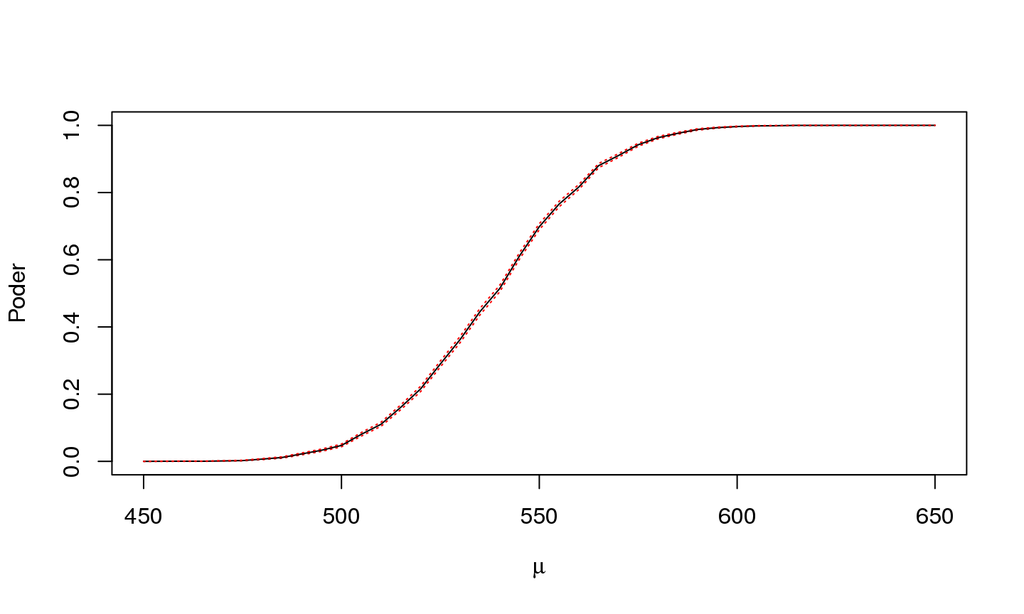

```r
matplot(mu1, cbind(power-1.96*err, power, power+1.96*err), col=c(2, 1, 2),
        type='l', xlab=expression(mu), ylab='Poder', lty=c(3, 1, 3))
```

## Referências

Capítulo 6 - Maria Rizzo - Statistical Computing with R